# Sobol Homework

Author

Marina Kochuten

# Assignment Part 1

Write a paragraph describing how results of the sensitivity analysis reported on in the paper might contribute to understanding (or prediction) within an environmental problem solving or management context.

**Exploring snow model parameter sensitivity using Sobol’ variance decomposition**

The sensitivity analysis presented in the paper provides insights for environmental problem solving by identifying which model parameters most significantly influence snow water equivalent (SWE) simulations. Knowing which parameters influence the outputs of these models allows modelers to be informed to prioritize accurate data collection and calibration for these most impactful variables. In the empirical SNOW-17 model MFMAX and PLWHC were the most impactful parameters, while in the physically-based VIC model, expA1 and expA2 were the most important factors. In this VIC model, expA1 and expA2 are currently fixed. This sensitivity analysis illuminates the importance of allowing these parameters to be adjusted based on user input, which can significantly improve SWE projections and therefore water management practices.

# Assignment Part 2

```r
# Load libraries
library(sensitivity)
library(tidyverse)
library(gridExtra)
library(purrr)
library(ggpubr)
library(here)
```

## Part a: Use the Sobel approach to generate parameter values for the 4 parameters

```r
# Source atmospheric conductance function
source(here("R/Catm.R"))

# Generate two examples of random number from parameter distributions
np <- 1000
k_o <- rnorm(mean = 0.1, sd = 0.1 * 0.01, n = np) # standard deviation is 1% of the default values
k_d <- rnorm(mean = 0.7, sd = 0.7 * 0.01, n = np) # standard deviation is 1% of the default values
v <- rnorm(mean = 3, sd = 0.5, n = np)
height <- runif(min = 3.5, max = 5.5, n = np)

X1 <- cbind.data.frame(k_o, k_d, v, height = height)

# repeat sampling
k_o <- rnorm(mean = 0.1, sd = 0.1 * 0.01, n = np) # standard deviation is 1% of the default values
k_d <- rnorm(mean = 0.7, sd = 0.7 * 0.01, n = np) # standard deviation is 1% of the default values
v <- rnorm(mean = 3, sd = 0.5, n = np)
height <- runif(min = 3.5, max = 5.5, n = np)

X2 <- cbind.data.frame(k_o, k_d, v, height = height)

# there are different versions of sobol functions that have different approaches for estimating parameters and indices, we use an approach implemented by jansen
sens_Catm_Sobol <- sobolSalt(model = NULL, X1, X2, nboot = 100)
```

## Part b: Run the atmospheric conductance model for these parameters

```r
# run model for all parameter sets
# make sure you give the parameters names

parms <- as.data.frame(sens_Catm_Sobol$X)
colnames(parms) <- colnames(X1)
res <- pmap_dbl(parms, Catm)

sens_Catm_Sobol <- sensitivity::tell(sens_Catm_Sobol, res, res.names = "ga")  # ga is short for atmospheric conductance
```

## Part e: Estimate the Sobel Indices for your outut

**Note:** I completed the steps out of order to match what we did in lecture, plotting will come after this!

```r
# main effect:  partitions variance (main effect without co-variance) - sums approximately to one
#sens_Catm_Sobol$S
# useful to add names
row.names(sens_Catm_Sobol$S) <- colnames(parms)
#sens_Catm_Sobol$S

# total effect - accounts for parameter interactions
row.names(sens_Catm_Sobol$T) <- colnames(parms)
#sens_Catm_Sobol$T

# Both the main effect and total effect can tell us something about how the parameter influences results

print(sens_Catm_Sobol)
```

[output not shown]

Most important parameter is windspeed, followed by height!

# Part c: Plot conductance estimates in a way that accounts for parameter uncertainty

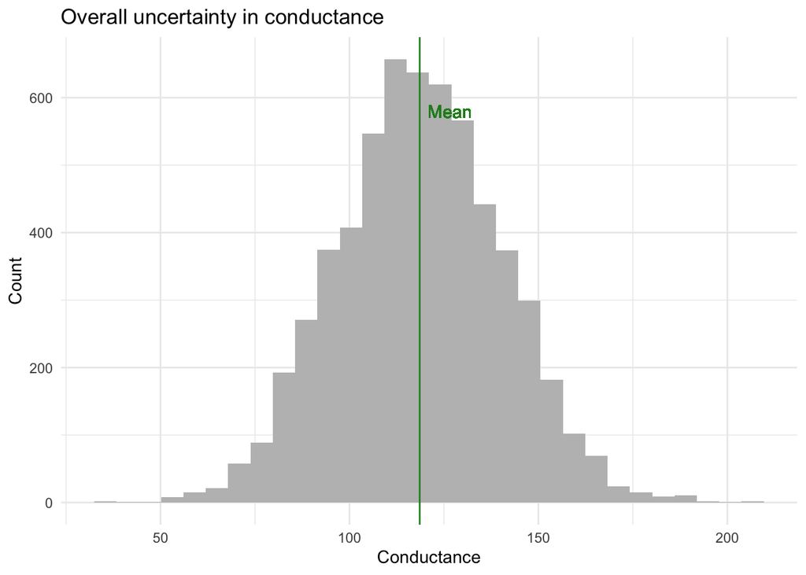

```r
# graph two most sensitive parameters
both <- cbind.data.frame(parms, gs = sens_Catm_Sobol$y)

# look at overall gs sensitvity to uncertainty
ggplot(both, aes(x = gs)) +
    geom_histogram(fill = "grey") +
    labs(x = "Conductance",
         y = "Count",
         title = "Overall uncertainty in conductance") +
    geom_vline(xintercept = mean(both$gs),
               col = "forestgreen") +
    geom_text(aes(x = mean(both$gs) + 8, y = 580, label = "Mean"), color = "forestgreen") +
    theme_minimal()
```

# Part d: Plot conductance estimates against windspeed use the parameter that is 2nd in terms of total effect on response

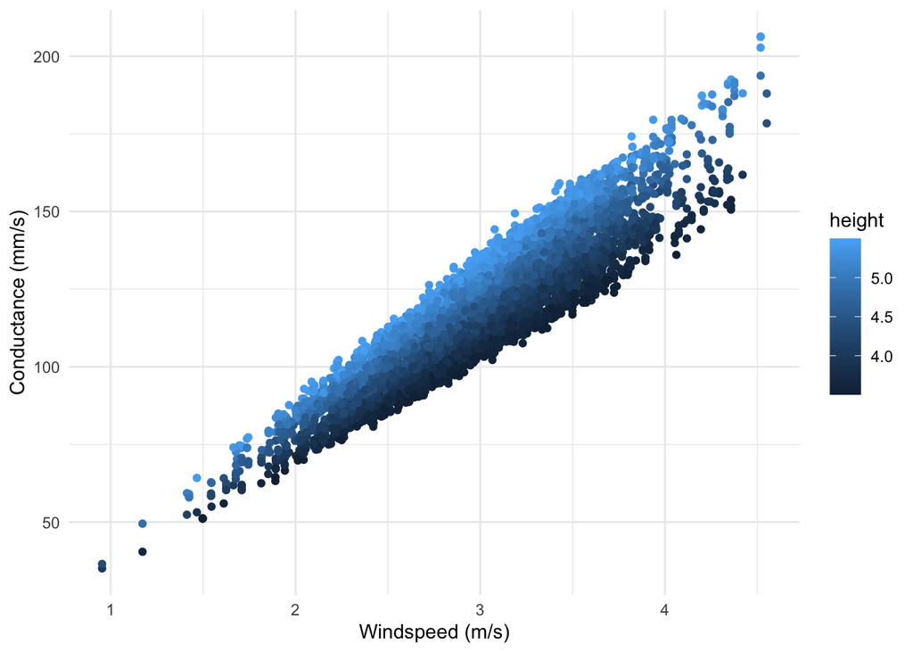

```r
# look at response of conductance to the two most important variables
ggplot(both, aes(v, gs, col = height)) +
    geom_point() +
    labs(y = "Conductance (mm/s)", x = "Windspeed (m/s)") +
    theme_minimal()
```

# Part f

**Comment on what this tells you about how atmospheric conductance and its sensitivity to variation in windspeed differs in this setting as compared to the setting that we examined in class where windspeed was lower and less variable and vegetation was taller**

In this setting where windspeed is higher and vegetation height is lower, atmospheric conductance is much more sensitive to windspeed (as seen by a stronger correlation in the graph) and height becomes the second most important parameter in terms of total effect on response. In the setting we saw in class, atmospheric conductance was the most sensitive to k_d, followed by k_o.

In other words, when vegetation is shorter and wind is stronger, conductance is more sensitive to changes in speed and height than the other parameters.